# Data Science Capstone - Course Project

John Cleveland  
01/02/2017

### Word Prediction

We all love our SWIFTKEY KEYBOARDS and GOOGLE SEARCH … some more than others …

[figure not shown]

AUTOCOMPLETER is a word predictor deployed using R framework: R language, R markdown , R Presenter, R Shiny … R everything!!!

Both word predictor and autocompleter! Fast Accurate ! Trained on blog, news and twitter data !

### Under the Hood

AUTOCOMPLETER uses n-gram Linear Interpolation Smoothing

The formulas are : \( p_{\lambda}( w_i|w_{i-3}, w_{i-2}, w_{i-1}) = \lambda_4 p_{4}( w_i|w_{i-3}, w_{i-2}, w_{i-1}) \) \( + \lambda_3 p_3( w_i| w_{i-2}, w_{i-1}) + \lambda_2 p_2( w_i| w_{i-1}) + \lambda_1 p_1( w_i) + \lambda_0/ |V| \)

- Normalize: \( \lambda_i >0 \) , \( \sum \lambda_i =1 \)

One can choose the \( \lambda_i 's \) according to some criteria or utilize MLE: [http://www.cs.jhu.edu/~hajic/courses/cs465/cs46506/ppframe.htm](http://www.cs.jhu.edu/%7Ehajic/courses/cs465/cs46506/ppframe.htm)

### Example Usage of Application

Just start typing !!

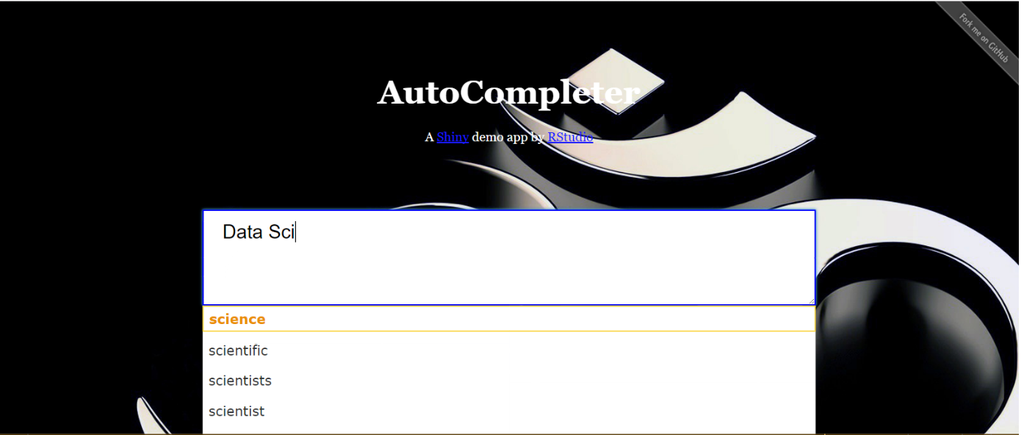

### Screen Shot

The source code can be obtained at the following repository :

https://github.com/johncleveland/Data-Science-Capstone

A prototype of AUTOCOMPLETER has been developed and deployed at:

https://yxs8495.shinyapps.io/Capstone_app/

For more details on authoring R presentations please visit https://support.rstudio.com/hc/en-us/articles/200486468.